# Analyzing Individual BGG Users

Phil Henrickson

2022-01-02

# **fishingking’s** BoardGameGeek Collection

This notebook contains a set of analyses for the selected user’s boardgamegeek collection. The bulk of the analysis is focused on building a user-specific predictive model to predict the games that fishingking is likely to own. This enables to ask questions like, based on the games the user currently owns, what games are a good fit for their collection? What upcoming games are they likely to purchase?

This analysis is based on data from BoardGameGeek that was last updated on **2021-12-20.**

# 1 Collection Overview

We can look at a basic description of the number of games that the user owns, has rated, has previously owned, etc.

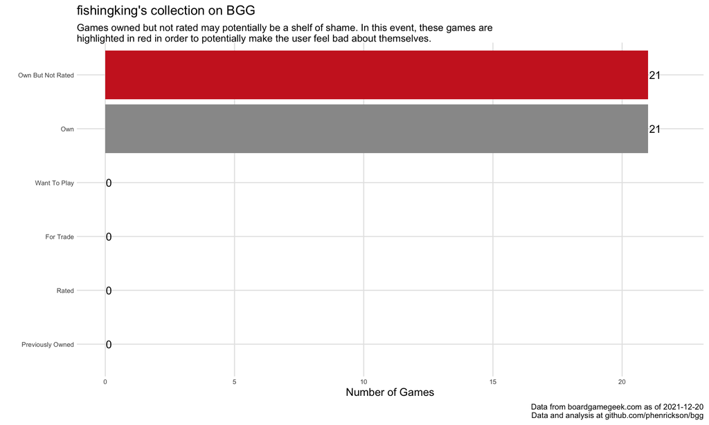

What years has the user owned/rated games from? While we can’t see when a user added or removed a game from their collection, we can look at their collection by the years in which their games were published.

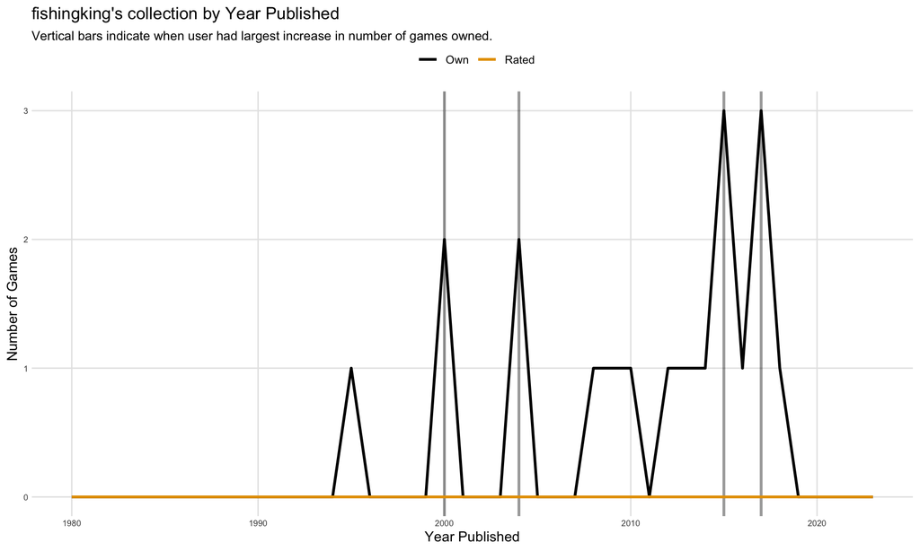

## 1.1 What types of games does fishingking own?

We can look at the most frequent types of categories, mechanics, designers, and artists that appear in a user’s collection.

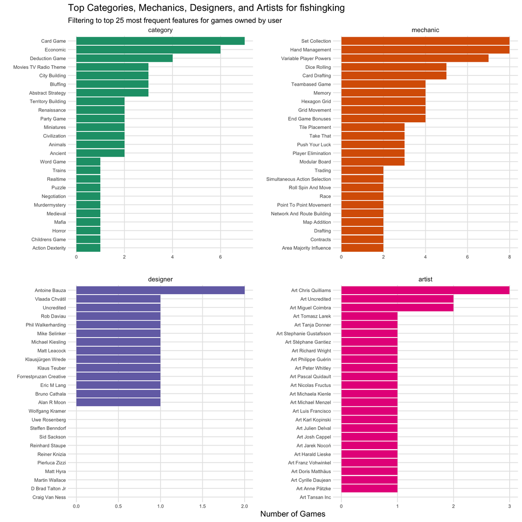

# 2 Modeling **fishingking’s** Collection

| username | dataset | period | games_owned | games_rated | games_played |
| --- | --- | --- | --- | --- | --- |
| fishingking | training | published before 2018 | 20 | 0 | 20 |
| fishingking | test | published 2018 or later | 1 | 0 | 1 |

There are two main (binary) outcomes we will be modeling for the user.

The first, **own** refers to whether the user currently lists a game as owned in their collection. The second, **played** refers to whether the user currently owns, has rated, or previously owned a game. This means the latter will generally have a larger list of games, but may still be a useful category to examine for people who play lots of games without necessarily owning them.

We will train predictive models to learn the probability that the user will own or play individual games based on their features.

## 2.1 Coefficients for fishingking

We can examine coefficients from the trained modes, which are penalized logistic regressions fit to our two main outcomes. Positive values indicate that a feature increases a user’s probabilility of owning/rating a game, while negative values indicate a feature decreases the probability.

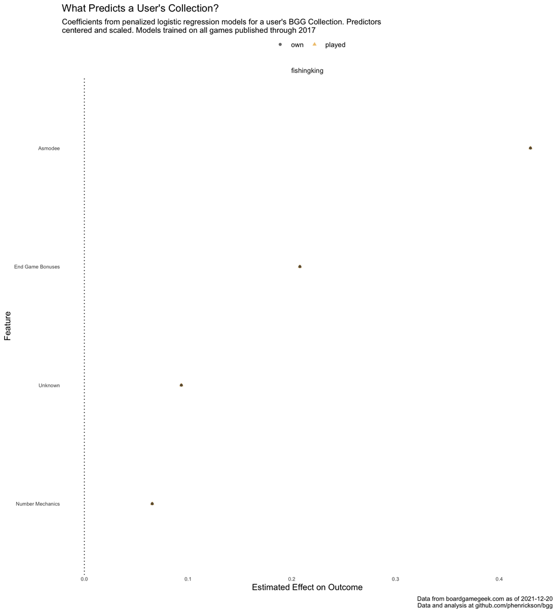

## 2.2 Visualizing Predictors for fishingking’s Collection

Why did the model identify these features? We can make density plots of the important features for predicting whether the user owned a game. Blue indicates the density for games owned by the user, while grey indicates the density for games not owned by the user.

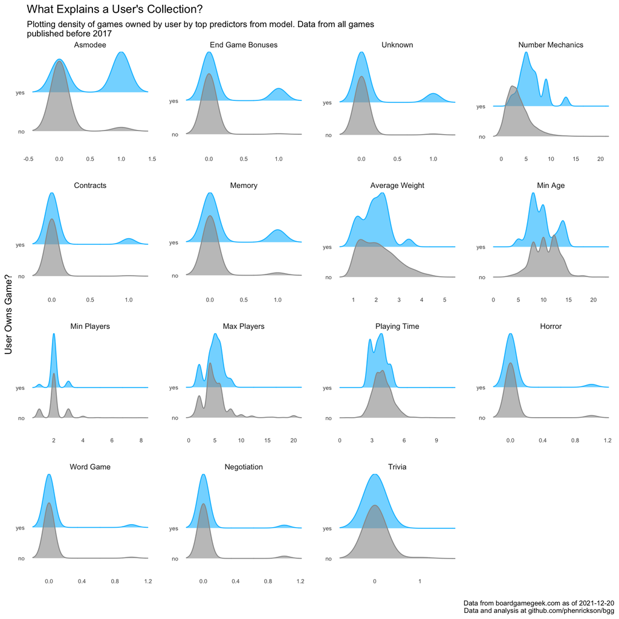

Binary predictors can be difficult to see with this visualization, so we can also directly examine the percentage of games in a user’s collection with a predictor vs the percentage of all games with that predictor.

| username | Feature | % of Games with Feature In_Collection | % of Games with Feature All_Games | Ratio |
| --- | --- | --- | --- | --- |
| fishingking | End Game Bonuses | 20.0% | 0.9% | 21.7 |
| fishingking | Contracts | 10.0% | 0.7% | 13.6 |
| fishingking | Asmodee | 55.0% | 5.1% | 10.8 |
| fishingking | Unknown | 15.0% | 1.7% | 8.8 |
| fishingking | Mafia | 5.0% | 0.7% | 7.3 |
| fishingking | Memory | 20.0% | 4.1% | 4.9 |
| fishingking | City Building | 15.0% | 4.1% | 3.7 |
| fishingking | Deduction Game | 20.0% | 6.0% | 3.3 |
| fishingking | Murdermystery | 5.0% | 1.6% | 3.1 |
| fishingking | Word Game | 5.0% | 1.8% | 2.8 |
| fishingking | Trains | 5.0% | 2.3% | 2.2 |
| fishingking | Puzzle | 5.0% | 2.8% | 1.8 |
| fishingking | Horror | 5.0% | 3.7% | 1.3 |
| fishingking | Negotiation | 5.0% | 4.0% | 1.3 |
| fishingking | Realtime | 5.0% | 4.0% | 1.2 |
| fishingking | Party Game | 10.0% | 8.8% | 1.1 |
| fishingking | Action Dexterity | 5.0% | 5.1% | 1.0 |
| fishingking | Medieval | 5.0% | 6.2% | 0.8 |
| fishingking | Childrens Game | 5.0% | 6.3% | 0.8 |
| fishingking | Fighting | 5.0% | 9.0% | 0.6 |
| fishingking | Trivia | 0.0% | 2.0% | 0.0 |
| fishingking | Racing | 0.0% | 3.1% | 0.0 |
| fishingking | Prehistoric | 0.0% | 1.0% | 0.0 |
| fishingking | Sports | 0.0% | 2.2% | 0.0 |
| fishingking | Memory Game | 0.0% | 1.9% | 0.0 |

# 3 Assess Model’s Performance on Training Set

Before predicting games in upcoming years, we can examine how well the model did and what games it liked in the training set. In this case, we used resampling techniques (cross validation) to ensure that the model had not seen a game before making its predictions.

## 3.1 Separation Plot

An easy way to examine the performance of classification model is to view a separation plot. We plot the predicted probabilities from the model for every game (from resampling) from lowest to highest. We then overlay a blue line for any game that the user does own. A good classifier is one that is able to *separate* the blue (games owned by the user) from the white (games not owned by the user), with most of the blue occurring at the highest probabilities (right side of the chart).

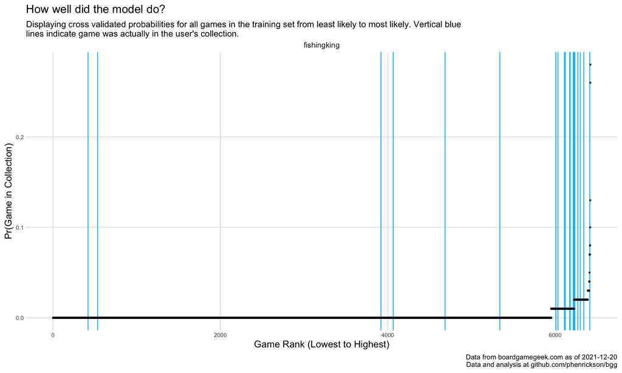

## 3.2 Top Games for **fishingking** from Training Set

We can display this information in table form, displaying the 100 games with the highest probability of ownership, adding a blue line when the user does own the game.

| username | yearpublished | game_id | name | pred_played | pred_own | actual_played | actual_own |
| --- | --- | --- | --- | --- | --- | --- | --- |
| fishingking | 2008 | 34635 | Stone Age | 0.28 | 0.28 | 0 | 0 |
| fishingking | 2011 | 70919 | Takenoko | 0.26 | 0.26 | 0 | 0 |
| fishingking | 2005 | 18258 | Mission: Red Planet | 0.13 | 0.13 | 0 | 0 |
| fishingking | 1948 | 320 | Scrabble | 0.10 | 0.10 | 0 | 0 |
| fishingking | 2010 | 73439 | Troyes | 0.08 | 0.08 | 0 | 0 |
| fishingking | 2010 | 62219 | Dominant Species | 0.08 | 0.08 | 0 | 0 |
| fishingking | 2016 | 176083 | Hit Z Road | 0.07 | 0.07 | 0 | 0 |
| fishingking | 2017 | 218603 | Photosynthesis | 0.07 | 0.07 | 0 | 0 |
| fishingking | 2017 | 230802 | Azul | 0.07 | 0.07 | 1 | 1 |
| fishingking | 2015 | 182874 | Grand Austria Hotel | 0.07 | 0.07 | 0 | 0 |
| fishingking | 2009 | 55600 | Shipyard | 0.05 | 0.05 | 0 | 0 |
| fishingking | 1980 | 2290 | Good & Bad Ghosts | 0.04 | 0.04 | 0 | 0 |
| fishingking | 2009 | 56885 | The Werewolves of Miller's Hollow: The Village | 0.04 | 0.04 | 0 | 0 |
| fishingking | 2012 | 123096 | Space Cadets | 0.04 | 0.04 | 0 | 0 |
| fishingking | 1990 | 2944 | Halli Galli | 0.04 | 0.04 | 0 | 0 |
| fishingking | 2014 | 155426 | Castles of Mad King Ludwig | 0.03 | 0.03 | 0 | 0 |
| fishingking | 2015 | 160744 | Far Space Foundry | 0.03 | 0.03 | 0 | 0 |
| fishingking | 2014 | 155987 | Abyss | 0.03 | 0.03 | 0 | 0 |
| fishingking | 2014 | 153938 | Camel Up | 0.03 | 0.03 | 0 | 0 |
| fishingking | 2016 | 192291 | Sushi Go Party! | 0.03 | 0.03 | 0 | 0 |
| fishingking | 2011 | 72125 | Eclipse | 0.03 | 0.03 | 0 | 0 |
| fishingking | 2013 | 127024 | Room 25 | 0.03 | 0.03 | 0 | 0 |
| fishingking | 2017 | 188920 | This War of Mine: The Board Game | 0.03 | 0.03 | 0 | 0 |
| fishingking | 2016 | 205045 | Avenue | 0.03 | 0.03 | 0 | 0 |
| fishingking | 2009 | 43015 | Hansa Teutonica | 0.03 | 0.03 | 0 | 0 |
| fishingking | 2016 | 156858 | Black Orchestra | 0.03 | 0.03 | 0 | 0 |
| fishingking | 2005 | 19857 | Glory to Rome | 0.03 | 0.03 | 0 | 0 |
| fishingking | 2002 | 3076 | Puerto Rico | 0.03 | 0.03 | 0 | 0 |
| fishingking | 2014 | 163920 | Gaïa | 0.03 | 0.03 | 0 | 0 |
| fishingking | 1996 | 270 | Svea Rike | 0.03 | 0.03 | 0 | 0 |

[output cut: 70 more lines]

We can also more formally assess how well the model did in resampling by looking at the area under the receiver operating characteristic. A perfect model would receive a score of 1, while a model that cannot predict the outcome will default to a score of 0.5. The extent to which something is a *good* score depends on the setting, but generally anything in the .8 to .9 range is very good while the .7 to .8 range is perfectly acceptable.

| username | outcome_type | .metric | .estimator | .estimate |
| --- | --- | --- | --- | --- |
| fishingking | own | roc_auc | binary | 0.792 |
| fishingking | played | roc_auc | binary | 0.792 |

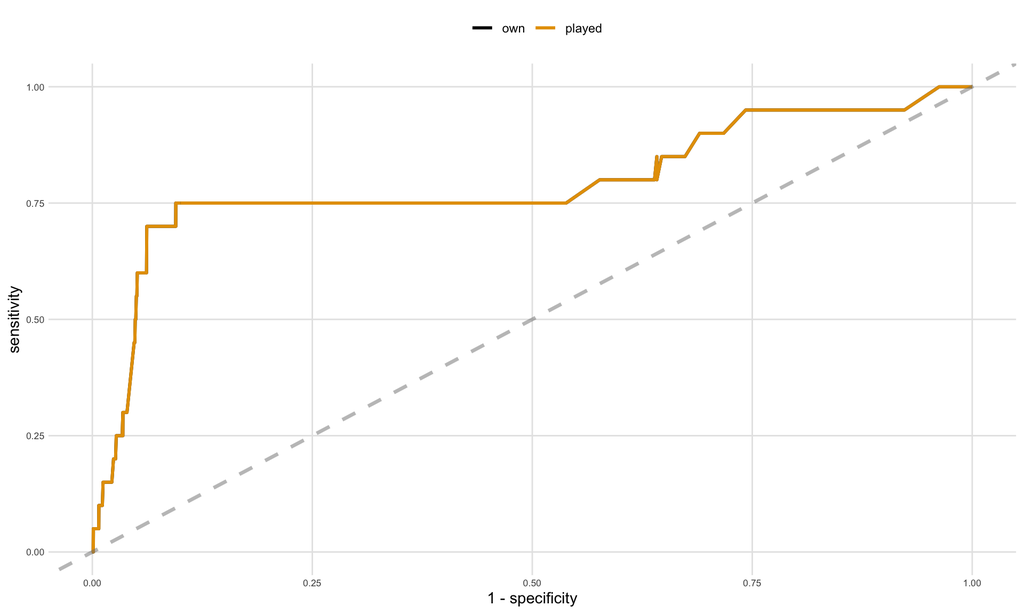

Another way to think about the model performance is to view its lift, or its ability to detect the positive outcomes over that of a null model. High lift indicates the model can much more quickly find all of the positive outcomes (in this case, games owned or played by the user), while a model with no lift is no better than random guessing.

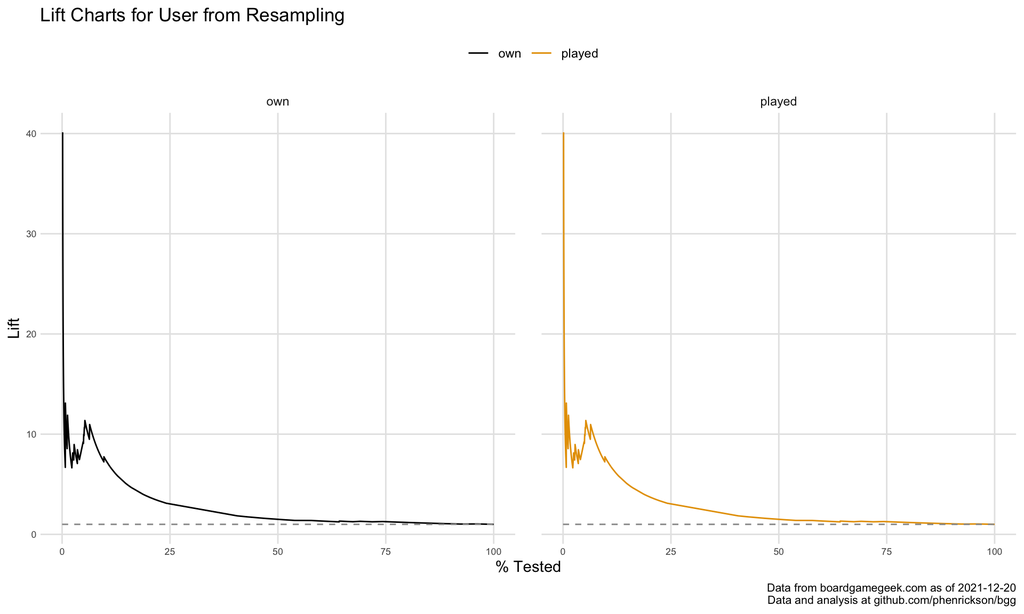

## 3.3 Most and Least Likely Games

What games does the model think fishingking is **most likely to own** that are **not** in their collection?

| username | yearpublished | game_id | name | pred_own | actual_own |
| --- | --- | --- | --- | --- | --- |
| fishingking | 2008 | 34635 | Stone Age | 0.28 | 0 |
| fishingking | 2011 | 70919 | Takenoko | 0.26 | 0 |
| fishingking | 2005 | 18258 | Mission: Red Planet | 0.13 | 0 |
| fishingking | 1948 | 320 | Scrabble | 0.10 | 0 |
| fishingking | 2010 | 73439 | Troyes | 0.08 | 0 |

What games does the model think fishingking is **least likely to own** that **are** in their collection?

| username | yearpublished | game_id | name | pred_own | actual_own |
| --- | --- | --- | --- | --- | --- |
| fishingking | 1900 | 2397 | Backgammon | 0 | 1 |
| fishingking | 2015 | 173346 | 7 Wonders Duel | 0 | 1 |
| fishingking | 2009 | 55763 | Mister X | 0 | 1 |
| fishingking | 1949 | 1294 | Clue | 0 | 1 |
| fishingking | 2017 | 220700 | Cobra Paw | 0 | 1 |

## 3.4 Top Games by Year

Top 25 games most likely to be owned by the user in each year, highlighting in blue the games that the user has owned/played.

| rank | 2009 | 2010 | 2011 | 2012 | 2013 | 2014 | 2015 | 2016 | 2017 |
| --- | --- | --- | --- | --- | --- | --- | --- | --- | --- |
| 1 | Shipyard | Troyes | Takenoko | Space Cadets | Room 25 | Castles of Mad King Ludwig | Grand Austria Hotel | Hit Z Road | Photosynthesis |
| 2 | The Werewolves of Miller's Hollow: The Village | Dominant Species | Eclipse | PIX | Dungeon Twister: The Card Game | Abyss | Far Space Foundry | Sushi Go Party! | Azul |
| 3 | Hansa Teutonica | Cyrano | Ascension: Return of the Fallen | Suburbia | Legacy: The Testament of Duke de Crecy | Camel Up | Exploding Kittens: NSFW Deck | Avenue | This War of Mine: The Board Game |
| 4 | Claustrophobia | Merchants & Marauders | Streams | Mice and Mystics | Berserk: War of the Realms | Gaïa | T.I.M.E Stories | Black Orchestra | Whitehall Mystery |
| 5 | Jaipur | Felinia | Ascension: Storm of Souls | Seasons | Corto | Akrotiri | Haspelknecht | Agricola: Family Edition | Pandemic Legacy: Season 2 |
| 6 | Bakong | Castaways | Flash Point: Fire Rescue | Santa Cruz | Koryŏ | Patchwork | Bastion | Pandemic: Reign of Cthulhu | Gaia Project |
| 7 | Monster Chase | Fabula | Seven Dragons | Divinare | BANG! The Dice Game | Saboteur: The Duel | The Pursuit of Happiness | Dream Home | Dice Forge |
| 8 | You Robot | Anomia | A Few Acres of Snow | City of Horror | Rory's Story Cubes: Prehistoria | Deus | Elysium | Mistfall: Heart of the Mists | Tsukiji |
| 9 | Nostra City | Hanabi | Village | Libertalia | Zombicide Season 2: Prison Outbreak | Arcadia Quest | Barony | Match Madness | A Tale of Pirates |
| 10 | String Railway | Expedition: Northwest Passage | The Secret of Monte Cristo | Dixit: Journey | Jungle Speed: Safari | Splendor | The Builders: Antiquity | Captain Sonar | Harvest Dice |
| 11 | Dungeon Twister 2: Prison | Engine, Engine No. 9 | Saga | Keyflower | Ladies & Gentlemen | Pictopia: Disney Edition | Bang! The Dice Game: The Walking Dead | Citadels | Gloomhaven |
| 12 | Ra: The Dice Game | Ascension: Deckbuilding Game | Mage Knight Board Game | Dixit Jinx | Brew Crafters | Hyperborea | Imagine | Codenames: Pictures | Dinosaur Island |
| 13 | Finca | Timeline: Inventions | Tetris Link | Coup | Circus Train (Second Edition) | Artificium | Codenames | Codenames: Deep Undercover | Civilization: A New Dawn |
| 14 | Atlantis | Time's Up! Family | Timeline: Discoveries | Gentlemen Thieves | Spyrium | Bucket of Doom | Salem 1692 | New Angeles | Sherlock Holmes Consulting Detective: Carlton House & Queen's Park |
| 15 | At the Gates of Loyang | 11 nimmt! | Timeline: Events | Kemet | Nations | Imperial Settlers | Watson & Holmes | Braintopia | Secrets |
| 16 | Hide the Kids! | 7 Wonders | Dixit: Odyssey | Targi | Rivet Wars: Eastern Front | Five Tribes | Tiny Epic Galaxies | When I Dream | Unlock!: Escape Adventures – Temple of Ra |
| 17 | Loco Motive | Asteroyds | Rory's Story Cubes: Voyages | Tzolk'in: The Mayan Calendar | Pizza Party | Black Fleet | Blood Rage | The Networks | Custom Heroes |
| 18 | Spot it! | Buzz It! | Letters from Whitechapel | Serenissima (Second Edition) | Prosperity | Isle of Trains | Steam Time | The Others | Unlock!: Escape Adventures – Fifth Avenue |
| 19 | Time's Up! Academy | Mousquetaires du Roy | Mundus Novus | Il Vecchio | Kashgar: Merchants of the Silk Road | La Granja | Raiders of the North Sea | Dynasties: Heirate & Herrsche | Massive Darkness |
| 20 | Mixmo | Nations at War: White Star Rising | Skull | Kairo | Ascension: Rise of Vigil | ZhanGuo | Discoveries: The Journals of Lewis & Clark | Game of Thrones: The Iron Throne | Catch the Moon |
| 21 | Cyclades | Battles of Napoleon: The Eagle and the Lion | Rumble in the House | Love Letter | The Builders: Middle Ages | Alchemists | The Bloody Inn | Thief's Market | Exploding Kittens: Party Pack |
| 22 | Small World | Washington's War | Québec | Wits & Wagers Party | Russian Railroads | Desperados of Dice Town | Tales & Games: The Grasshopper & the Ant | Bloodborne: The Card Game | Calimala |
| 23 | Dice Town | Commands & Colors: Napoleonics | Evo (Second Edition) | Timeline | Cappuccino | Continental Express | Nippon | Terraforming Mars | Century: Spice Road |
| 24 | Name 5 | Hearts and Minds: Vietnam 1965-1975 | Undermining | Cardline: Animals | Mascarade | Chosŏn | 504 | The Manhattan Project: Energy Empire | Paper Tales |
| 25 | Waterloo | Battle Above the Clouds | Tales & Games: The Hare & the Tortoise | Timeline: General Interest | Timeline: Music & Cinema | Witness | The Voyages of Marco Polo | 13 Days: The Cuban Missile Crisis | Purrrlock Holmes: Furriarty's Trail |

## 3.5 Interactive Predictions from Resampling

Interactive table for predictions from resampling.

|  | username | yearpublished | rank | game_id | name | pred_played | pred_own | actual_played | actual_own |
| --- | --- | --- | --- | --- | --- | --- | --- | --- | --- |
| 1 | fishingking | 1900 | 121 | 15878 | Rummy | 0.02 | 0.02 | 0 | 0 |
| 2 | fishingking | 1900 | 196 | 171 | Chess | 0.01 | 0.01 | 0 | 0 |
| 3 | fishingking | 1900 | 197 | 2065 | Shogi | 0.01 | 0.01 | 0 | 0 |
| 4 | fishingking | 1900 | 204 | 2083 | Checkers | 0.01 | 0.01 | 0 | 0 |
| 5 | fishingking | 1900 | 205 | 2389 | Othello | 0.01 | 0.01 | 0 | 0 |
| 6 | fishingking | 1900 | 210 | 2932 | Hnefatafl | 0.01 | 0.01 | 0 | 0 |
| 7 | fishingking | 1900 | 218 | 13713 | Solitaire | 0.01 | 0.01 | 0 | 0 |
| 8 | fishingking | 1900 | 266 | 2398 | Cribbage | 0.01 | 0.01 | 0 | 0 |
| 9 | fishingking | 1900 | 268 | 21389 | Happy Families | 0.01 | 0.01 | 0 | 0 |
| 10 | fishingking | 1900 | 333 | 6819 | Skat | 0.01 | 0.01 | 0 | 0 |

[output cut: 6410 more lines]

# 4 Validating the Model on 2018

How well did a model trained on a user’s collection through 2017 perform in predicting games for the user from 2018?

| username | outcome_type | yearpublished | .metric | .estimator | .estimate |
| --- | --- | --- | --- | --- | --- |
| fishingking | own | 2018 | roc_auc | binary | 0.825 |
| fishingking | played | 2018 | roc_auc | binary | 0.825 |

Table of top 25 games from 2018, highlighting games that the user owns.

| username | yearpublished | game_id | name | pred_own | pred_played | actual_own | actual_played |
| --- | --- | --- | --- | --- | --- | --- | --- |
| fishingking | 2018 | 205896 | Rising Sun | 0.15 | 0.15 | 0 | 0 |
| fishingking | 2018 | 258444 | Gingerbread House | 0.14 | 0.14 | 0 | 0 |
| fishingking | 2018 | 256226 | Azul: Stained Glass of Sintra | 0.12 | 0.12 | 0 | 0 |
| fishingking | 2018 | 199792 | Everdell | 0.02 | 0.02 | 0 | 0 |
| fishingking | 2018 | 205477 | Vengeance | 0.02 | 0.02 | 0 | 0 |
| fishingking | 2018 | 209324 | The World of SMOG: Rise of Moloch | 0.02 | 0.02 | 0 | 0 |
| fishingking | 2018 | 222219 | Kero | 0.02 | 0.02 | 0 | 0 |
| fishingking | 2018 | 222509 | Lords of Hellas | 0.02 | 0.02 | 0 | 0 |
| fishingking | 2018 | 232405 | Western Legends | 0.02 | 0.02 | 0 | 0 |
| fishingking | 2018 | 233020 | Fireball Island: The Curse of Vul-Kar | 0.02 | 0.02 | 0 | 0 |
| fishingking | 2018 | 242574 | Century: Eastern Wonders | 0.02 | 0.02 | 0 | 0 |
| fishingking | 2018 | 244331 | Blue Lagoon | 0.02 | 0.02 | 0 | 0 |
| fishingking | 2018 | 244711 | Newton | 0.02 | 0.02 | 0 | 0 |
| fishingking | 2018 | 245638 | Coimbra | 0.02 | 0.02 | 0 | 0 |
| fishingking | 2018 | 245928 | Pax Emancipation | 0.02 | 0.02 | 0 | 0 |
| fishingking | 2018 | 246192 | Gizmos | 0.02 | 0.02 | 0 | 0 |
| fishingking | 2018 | 246297 | Shadows: Amsterdam | 0.02 | 0.02 | 0 | 0 |
| fishingking | 2018 | 247236 | Duelosaur Island | 0.02 | 0.02 | 0 | 0 |
| fishingking | 2018 | 247763 | Underwater Cities | 0.02 | 0.02 | 0 | 0 |
| fishingking | 2018 | 252328 | Star Wars: X-Wing (Second Edition) | 0.02 | 0.02 | 0 | 0 |
| fishingking | 2018 | 253106 | Narcos: The Board Game | 0.02 | 0.02 | 0 | 0 |
| fishingking | 2018 | 254591 | Heroes of Terrinoth | 0.02 | 0.02 | 0 | 0 |
| fishingking | 2018 | 257321 | Gen7: A Crossroads Game | 0.02 | 0.02 | 0 | 0 |
| fishingking | 2018 | 257499 | Arkham Horror (Third Edition) | 0.02 | 0.02 | 0 | 0 |
| fishingking | 2018 | 260428 | Pandemic: Fall of Rome | 0.02 | 0.02 | 0 | 0 |

# 5 Predicting Upcoming Games (2018 and On) for **fishingking**

Examine the top games for the test set.

| username | yearpublished | game_id | name | rank | own | played |
| --- | --- | --- | --- | --- | --- | --- |
| fishingking | 2018 | 205896 | Rising Sun | 1 | 0.15 | 0.15 |
| fishingking | 2018 | 258444 | Gingerbread House | 2 | 0.14 | 0.14 |
| fishingking | 2018 | 256226 | Azul: Stained Glass of Sintra | 3 | 0.12 | 0.12 |
| fishingking | 2018 | 247236 | Duelosaur Island | 4 | 0.02 | 0.02 |
| fishingking | 2018 | 252328 | Star Wars: X-Wing (Second Edition) | 5 | 0.02 | 0.02 |
| fishingking | 2018 | 253106 | Narcos: The Board Game | 6 | 0.02 | 0.02 |
| fishingking | 2018 | 254591 | Heroes of Terrinoth | 7 | 0.02 | 0.02 |
| fishingking | 2018 | 257499 | Arkham Horror (Third Edition) | 8 | 0.02 | 0.02 |
| fishingking | 2018 | 205477 | Vengeance | 9 | 0.02 | 0.02 |
| fishingking | 2018 | 209324 | The World of SMOG: Rise of Moloch | 10 | 0.02 | 0.02 |
| fishingking | 2018 | 233020 | Fireball Island: The Curse of Vul-Kar | 11 | 0.02 | 0.02 |
| fishingking | 2018 | 222509 | Lords of Hellas | 12 | 0.02 | 0.02 |
| fishingking | 2018 | 246297 | Shadows: Amsterdam | 13 | 0.02 | 0.02 |
| fishingking | 2018 | 260428 | Pandemic: Fall of Rome | 14 | 0.02 | 0.02 |
| fishingking | 2018 | 257321 | Gen7: A Crossroads Game | 15 | 0.02 | 0.02 |
| fishingking | 2018 | 246192 | Gizmos | 16 | 0.02 | 0.02 |
| fishingking | 2018 | 199792 | Everdell | 17 | 0.02 | 0.02 |
| fishingking | 2018 | 245638 | Coimbra | 18 | 0.02 | 0.02 |
| fishingking | 2018 | 247763 | Underwater Cities | 19 | 0.02 | 0.02 |
| fishingking | 2018 | 242574 | Century: Eastern Wonders | 20 | 0.02 | 0.02 |
| fishingking | 2018 | 244331 | Blue Lagoon | 21 | 0.02 | 0.02 |
| fishingking | 2018 | 232405 | Western Legends | 22 | 0.02 | 0.02 |
| fishingking | 2018 | 245928 | Pax Emancipation | 23 | 0.02 | 0.02 |
| fishingking | 2018 | 222219 | Kero | 24 | 0.02 | 0.02 |
| fishingking | 2018 | 244711 | Newton | 25 | 0.02 | 0.02 |
| fishingking | 2019 | 270971 | Era: Medieval Age | 1 | 0.13 | 0.13 |
| fishingking | 2019 | 251247 | Barrage | 2 | 0.03 | 0.03 |
| fishingking | 2019 | 283863 | The Magnificent | 3 | 0.03 | 0.03 |
| fishingking | 2019 | 276025 | Maracaibo | 4 | 0.03 | 0.03 |
| fishingking | 2019 | 238992 | Call to Adventure | 5 | 0.02 | 0.02 |
| fishingking | 2019 | 245655 | The King's Dilemma | 6 | 0.02 | 0.02 |
| fishingking | 2019 | 248065 | Zombicide: Invader | 7 | 0.02 | 0.02 |
| fishingking | 2019 | 266304 | MegaCity: Oceania | 8 | 0.02 | 0.02 |
| fishingking | 2019 | 283294 | Yukon Airways | 9 | 0.02 | 0.02 |
| fishingking | 2019 | 284333 | Yggdrasil Chronicles | 10 | 0.02 | 0.02 |
| fishingking | 2019 | 285774 | Marvel Champions: The Card Game | 11 | 0.02 | 0.02 |
| fishingking | 2019 | 230244 | Black Angel | 12 | 0.02 | 0.02 |
| fishingking | 2019 | 269385 | The Lord of the Rings: Journeys in Middle-Earth | 13 | 0.02 | 0.02 |
| fishingking | 2019 | 282131 | Monster Baby Rescue! | 14 | 0.02 | 0.02 |
| fishingking | 2019 | 285984 | Last Bastion | 15 | 0.02 | 0.02 |
| fishingking | 2019 | 261342 | Old West Empresario | 16 | 0.02 | 0.02 |
| fishingking | 2019 | 266830 | Q.E. | 17 | 0.02 | 0.02 |
| fishingking | 2019 | 269144 | Hadara | 18 | 0.02 | 0.02 |
| fishingking | 2019 | 275010 | De Vulgari Eloquentia: Deluxe Edition | 19 | 0.02 | 0.02 |
| fishingking | 2019 | 287954 | Azul: Summer Pavilion | 20 | 0.02 | 0.02 |
| fishingking | 2019 | 266192 | Wingspan | 21 | 0.02 | 0.02 |
| fishingking | 2019 | 269603 | Minecraft: Builders & Biomes | 22 | 0.02 | 0.02 |
| fishingking | 2019 | 264982 | Coloma | 23 | 0.02 | 0.02 |
| fishingking | 2019 | 271324 | It's a Wonderful World | 24 | 0.02 | 0.02 |
| fishingking | 2019 | 280480 | Crystal Palace | 25 | 0.02 | 0.02 |
| fishingking | 2020 | 291874 | Dwergar | 1 | 0.11 | 0.11 |
| fishingking | 2020 | 300322 | Hallertau | 2 | 0.03 | 0.03 |
| fishingking | 2020 | 184267 | On Mars | 3 | 0.03 | 0.03 |
| fishingking | 2020 | 310448 | Zombie Teenz Evolution | 4 | 0.02 | 0.02 |
| fishingking | 2020 | 316377 | 7 Wonders (Second Edition) | 5 | 0.02 | 0.02 |
| fishingking | 2020 | 314040 | Pandemic Legacy: Season 0 | 6 | 0.02 | 0.02 |
| fishingking | 2020 | 302723 | Forgotten Waters | 7 | 0.02 | 0.02 |
| fishingking | 2020 | 297895 | Divvy Dice | 8 | 0.02 | 0.02 |
| fishingking | 2020 | 316554 | Dune: Imperium | 9 | 0.02 | 0.02 |
| fishingking | 2020 | 296557 | Zen Garden | 10 | 0.02 | 0.02 |
| fishingking | 2020 | 300081 | Hideous Abomination | 11 | 0.02 | 0.02 |
| fishingking | 2020 | 254888 | High Rise | 12 | 0.02 | 0.02 |
| fishingking | 2020 | 310968 | Bite and Write: The Treaty of Rodentia | 13 | 0.02 | 0.02 |
| fishingking | 2020 | 311193 | Anno 1800 | 14 | 0.02 | 0.02 |
| fishingking | 2020 | 279537 | The Search for Planet X | 15 | 0.02 | 0.02 |
| fishingking | 2020 | 297204 | Traintopia | 16 | 0.02 | 0.02 |
| fishingking | 2020 | 298371 | Wild Space | 17 | 0.02 | 0.02 |
| fishingking | 2020 | 299960 | Alma Mater | 18 | 0.02 | 0.02 |
| fishingking | 2020 | 310885 | Belaad: The Land of Swords and Quills | 19 | 0.02 | 0.02 |
| fishingking | 2020 | 279198 | Tungaru | 20 | 0.02 | 0.02 |
| fishingking | 2020 | 296483 | The Great Race | 21 | 0.02 | 0.02 |
| fishingking | 2020 | 277927 | Bites | 22 | 0.02 | 0.02 |
| fishingking | 2020 | 293889 | Fallout Shelter: The Board Game | 23 | 0.02 | 0.02 |
| fishingking | 2020 | 299592 | Beez | 24 | 0.02 | 0.02 |
| fishingking | 2020 | 302310 | Nanaki | 25 | 0.02 | 0.02 |

## 5.1 Interactive Table for Upcoming Games 2018 and On

|  | username | yearpublished | game_id | name | rank | own | played |
| --- | --- | --- | --- | --- | --- | --- | --- |
| 1 | fishingking | 2018 | 205896 | Rising Sun | 1 | 0.15 | 0.15 |
| 2 | fishingking | 2018 | 258444 | Gingerbread House | 2 | 0.14 | 0.14 |
| 3 | fishingking | 2019 | 270971 | Era: Medieval Age | 3 | 0.13 | 0.13 |
| 4 | fishingking | 2018 | 256226 | Azul: Stained Glass of Sintra | 4 | 0.12 | 0.12 |
| 5 | fishingking | 2020 | 291874 | Dwergar | 5 | 0.11 | 0.11 |
| 6 | fishingking | 2019 | 251247 | Barrage | 6 | 0.03 | 0.03 |
| 7 | fishingking | 2020 | 300322 | Hallertau | 7 | 0.03 | 0.03 |
| 8 | fishingking | 2019 | 283863 | The Magnificent | 8 | 0.03 | 0.03 |
| 9 | fishingking | 2019 | 276025 | Maracaibo | 9 | 0.03 | 0.03 |
| 10 | fishingking | 2020 | 184267 | On Mars | 10 | 0.03 | 0.03 |

[output cut: 1923 more lines]